# Review of the current state of PMDD scientific literature in Pubmed

### How does keyword utilization change over time?

I was then curious to see how keywords utilization changed over time. To do this, I looked at the number of publications using each keyword over time, regardless of when the keyword was first used. The following two graphs show the number of publications for each keyword when the publication date was before 2019, or on or after 2019. I was surprised to see that PMDD and PMS are both used in more publications after 2019. PMDD was used as a keyword in 108 publications before 2019 and 181 publications on or after 2019. Similarly, PMS appeared in 70 publications before 2019 and 106 after.

[figure not shown]

```r
# Plot the number of publications for the top 20 keywords used for the first time on 2019 or after
ggplot(data = head(filter(keywords, first_date >= 2019), n=30), aes(x = fct_reorder(keyword, publications), y = publications) ) +
  geom_col() +
  coord_flip() + scale_y_continuous(name="Number of publications") +
  scale_x_discrete(name="Keyword")
```

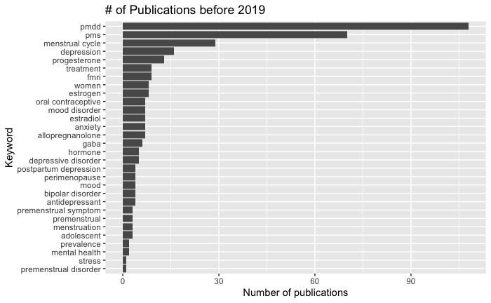

```r
# Plot the number of publications before 2019 for the top 20 keywords
ggplot(data = head(keywords, n=30), aes(x = fct_reorder(keyword, pubs_before_2019), y = pubs_before_2019) ) +
  geom_col() +
  coord_flip() + scale_y_continuous(name="Number of publications") +
  scale_x_discrete(name="Keyword") +
  ggtitle("# of Publications before 2019")
```

Seeing that both “PMDD” and “PMS” were used in more publications on or after 2019 than in the ~20 years before, I was curious to see with more granularity how these terms were used over the years.

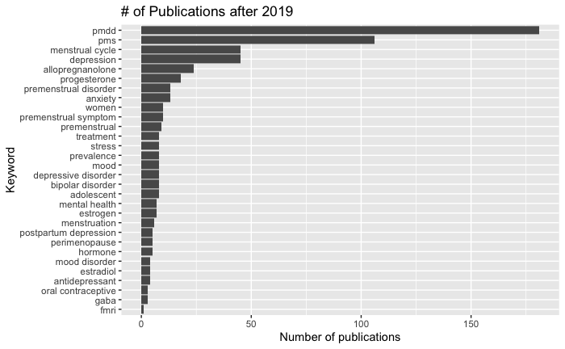

```r
# Plot the number of publications on or after 2019 for the top 20 keywords
ggplot(data = head(keywords, n=30), aes(x = fct_reorder(keyword, pubs_after_2019), y = pubs_after_2019) ) +
  geom_col() +
  coord_flip() + scale_y_continuous(name="Number of publications") +
  scale_x_discrete(name="Keyword") +
  ggtitle("# of Publications after 2019")
```

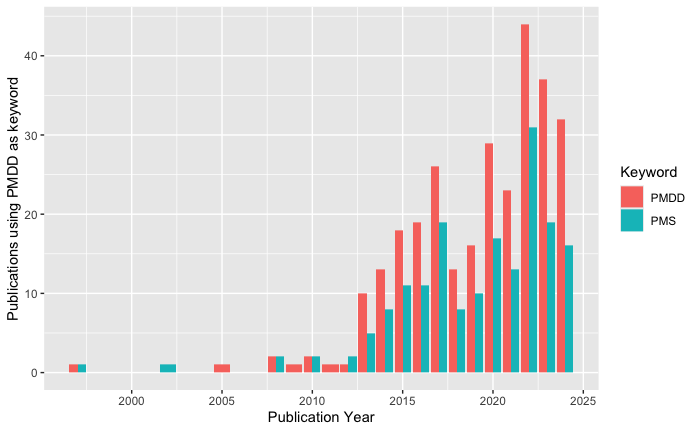

```r
# How did the use of the term PMDD change over time?
entrez_clean %>%
  unnest(keywords) %>%
  left_join(stg_kws, relationship = "many-to-many") %>%
  filter(lower_kw %in% c("pmdd","pms")) %>%
  #filter(lower_kw %in% c("pmdd","pms", "progesterone", "allopregnanolone", "estrogen", "estradiol", "gaba")) %>%
  group_by(lower_kw, publication_year) %>%
  summarize(., publications = n_distinct(pubmed_id)
            ) %>%
  ggplot(., aes(x = publication_year, y = publications, fill = toupper(lower_kw))) + geom_col(position = position_dodge()) + xlab("Publication Year") + ylab("Publications using PMDD as keyword") + scale_fill_discrete(name = "Keyword")
```